# Workflow with Caret

pauke

1/26/2019

```r
library(knitr)
library(caret)
library(DiagrammeR)#for the flowchart
library(DescTools)# for summary of data
library(proxy)#maxDissim
library(mlbench)#data zoo
library(data.table)
library(fastDummies) #for dummy variables

options(scipen=8)
```

## Foreword

This is a workflow about [caret](https://topepo.github.io/caret/), which is a creating predicted models collecting toolkit framework, integrating all activities related to model development from other R packages. Caret can be also treated as a tool to get started or get familiar with machine learning, especially in supervised and unsupervised learning part that is good at.

The article is about the usual thought of using caret and machine learning, more focusing on general use situation. And I’ll try to offer a holistic view for machine learning beginners and the way to find more concrete field. That means I would not present the specific algorithms, tuning methods or fitted fields.

## Structure

All tools in caret can be classified in the [ducument](https://topepo.github.io/caret/) like this:

> - data splitting
> - pre-processing(depending on data set situation)
> - feature selection
> - model tuning using resampling
> - variable importance estimation

Link to the crucial function in each part, all the part of caret workflow is:

[interactive chart not shown]

By the way,as I said in foreword, this post would like more pay attention on the process of caret using. The part of data exploration is deeply dependent on the familiarity about the data you get to deal with, and can be replaced by another professional packages. If you are more interesting on the visualization tools of caret, just jump to this [chapter](http://topepo.github.io/caret/visualizations.html).

## Data Splitting

More specific matter of data splitting, you can find on the [document](http://topepo.github.io/caret/data-splitting.html) and the this article [Preprocessign Data with caret](http://rismyhammer.com/ml/Pre-Processing.html)

| situation | splitting mathods |
| --- | --- |
| supervised learning | `createDataPartition()` |
| unsupervised learning | `maxDissim()` |
| time serias | `trainControl(method = "timeslice"...)` |

### Based on Outcome

`createDataPartition()` is the splitting function that data set has clear dependent variables, which means it’s fitted for supervised learning. `createDataPartition()`is the one of the most useful feature function of caret package, which makes data splitting to be more orderly and approachable.

This method can generate balant data split. When the dependent variables are factor variables, the splitting will based on the distribution of factors.

```r
data(scat)
#set seed and create splitting index
set.seed(3456)
trainIndex <- createDataPartition(scat$Species, p = .8,
                                  list = FALSE,
                                  times = 1)
#the distribution of dependent variables
knitr::kable(Desc(scat$Species)[[1]][["freq"]])
```

| level | freq | perc | cumfreq | cumperc |
| --- | --- | --- | --- | --- |
| bobcat | 57 | 0.5181818 | 57 | 0.5181818 |
| coyote | 28 | 0.2545455 | 85 | 0.7727273 |
| gray_fox | 25 | 0.2272727 | 110 | 1.0000000 |

```r
#splitting

scatTrain <- scat[ trainIndex,]
scatTest  <- scat[-trainIndex,]

knitr::kable(Desc(scatTrain$Species)[[1]][["freq"]])
```

| level | freq | perc | cumfreq | cumperc |
| --- | --- | --- | --- | --- |
| bobcat | 46 | 0.5168539 | 46 | 0.5168539 |
| coyote | 23 | 0.2584270 | 69 | 0.7752809 |
| gray_fox | 20 | 0.2247191 | 89 | 1.0000000 |

### Based on Predictors

If we manage to get a unsupervised learning prediction, the maxDissim function is a splitting good way using a maximum dissimilarity approach. About the method:

> Suppose there is a data set A with m samples and a larger data set B with n samples. We may want to create a sub–sample from B that is diverse when compared to A. To do this, for each sample in B, the function calculates the m dissimilarities between each point in A. The most dissimilar point in B is added to A and the process continues.

In a short, sampling out A as the start set, and getting the final set against start set by largest distance.

```r
data(cars)

testing <- scale(cars[, c("Price", "Mileage")])
set.seed(5)
## A random sample of 5 data points
startSet <- sample(1:dim(testing)[1], 5)
samplePool <- testing[-startSet,]
start <- testing[startSet,]
newSamp <- maxDissim(start, samplePool, n = 20)
```

result of the splitting:

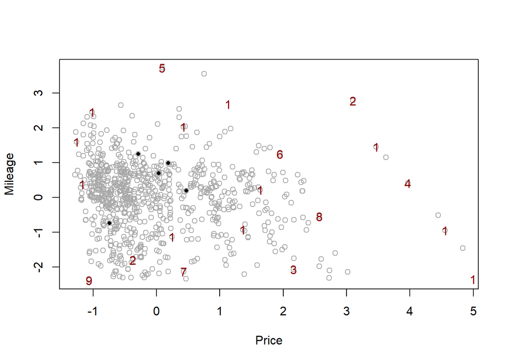

```r
plot(testing[-newSamp,],
          col = "darkgrey")
points(start, pch = 16, cex = .7)

     for(i in seq(along = newSamp))
          points(
               samplePool[newSamp[i],1],
               samplePool[newSamp[i],2],
               pch = paste(i), col = "darkred")
```

More maxDissim methods, please check this [article](http://rismyhammer.com/ml/Pre-Processing.html)’s Splitting Based on Predictors part.

### Time Serias Data Splitting

`createTimeSlices()` is the sister function of `createDataPartition()` to handle time serias data. Three argument of the function is:

- `initialWindow`: the initial number of consecutive values in each training set sample
- `horizon`: The number of consecutive values in test set sample
- `fixedWindow`: A logical: if FALSE, the training set always start at the first sample and the training set size will vary over data splits.

The example of the function usage is also in this [articles](http://rismyhammer.com/ml/Pre-Processing.html)’s Time Series Data Splitting part.

```r
data(economics)
# which is often used in the `trainControl()` set
myTimeControl <- trainControl(method = "timeslice", initialWindow = 36, horizon = 12, fixedWindow = TRUE)

plsFitTime <- train(unemploy ~ pce + pop + psavert, data = economics, method = "pls",
                    preProc = c("center", "scale"), trControl = myTimeControl)
```

## Preprocessing

This part is based on the conclution of your data exploration. You need to consider what situation of your data that you need to deal with before starting build your model. According to the situation of the function facing to, preprocessing function of caret can be sorted as:

| situation category | function |
| --- | --- |
| categorical/dichotomous variables | `dummyVars()`,`data.table()` |
| unbalance | `nearZeroVar()`,`preProcess(df,method = c("center", "scale"))` |
| missing value | `preProcess(df,method = c("center", "scale")/"knnImpute")` |
| too much predictors | `preProcess(df, method = "BoxCox"/"pca")` |
| class distance | `classDist()` |

As you can see, there are a lot of situations that might causes model prediction fail, and there are more solution to fix the situations you face. No matter how unique you are getting the data set problems, **stable, numerical, centralized and no missing** data set may lead a better result of model.

### `preProcess()` Function Set

Package caret provised a useful function,`preProcess()`,to handle the preprocessing’s situations.

Function preProcess contain two parts: `preProcess()`procession and `predict.preProcess()`procession. `preProcess()`estimates the required parameters for each operation and `predict.preProcess()` is used to apply them to specific data sets. This function can also be interfaces when calling the train function.

`preProcValues <- preProcess(dataToHandle, method = c(),...other Arguments)` `dataTransformed <- predict(preProcValues, dataToHandle)`

Specific example:

```r
data(oil)

inTrain <- sample(seq(along = fattyAcids), length(fattyAcids)*0.7)

training <- fattyAcids[inTrain,]
str(training)
```

```
## 'data.frame':    4 obs. of  7 variables:
##  $ Palmitic  : num  9.8 11.5 12.2 9.7
##  $ Stearic   : num  4.2 5.2 5 5.2
##  $ Oleic     : num  43 35 31.1 31
##  $ Linoleic  : num  39.2 47.2 50.5 52.7
##  $ Linolenic : num  2.4 0.2 0.3 0.4
##  $ Eicosanoic: num  0.4 0.4 0.4 0.4
##  $ Eicosenoic: num  0.5 0.1 0.1 0.1
```

```r
preProcValues <- preProcess(training, method = c("center", "scale"))

trainTransformed <- predict(preProcValues, training)
str(trainTransformed)
```

```
## 'data.frame':    4 obs. of  7 variables:
##  $ Palmitic  : num  -0.802 0.562 1.123 -0.883
##  $ Stearic   : num  -1.47 0.63 0.21 0.63
##  $ Oleic     : num  1.41565 -0.00444 -0.69673 -0.71448
##  $ Linoleic  : num  -1.3862 -0.0338 0.524 0.8959
##  $ Linolenic : num  1.495 -0.593 -0.498 -0.404
##  $ Eicosanoic: num  0 0 0 0
##  $ Eicosenoic: num  1.5 -0.5 -0.5 -0.5
```

The list of function preProcess methods:

- **range**: Normalize values so it ranges between 0 and 1
- **center**: Subtract Mean
- **scale**: Divide by standard deviation
- **BoxCox**: Remove skewness leading to normality. Values must be > 0
- **YeoJohnson**: Like BoxCox, but works for negative values.
- **expoTrans**: Exponential transformation, works for negative values.
- **pca**: Replace with principal components
- **ica**: Replace with independent components
- **spatialSign**: Project the data to a unit circle

More information about how function preProcess is used, you can find in `??preProcess` and this [article](http://rismyhammer.com/ml/Pre-Processing.html#split-data)

### Other preprocessing function

#### Turning Numerical

There are two methods to deal with the categorical or dichotomous variables:

##### Recode the Categorical Variable as Numeric

```r
data("Zoo")
Zoo$animalNames <- rownames(Zoo)

#categorical variable
unique(Zoo$type)
```

```
## [1] mammal        fish          bird          mollusc.et.al insect
## [6] amphibian     reptile
## Levels: mammal bird reptile fish amphibian insect mollusc.et.al
```

```r
## recode the categorical variable as numeric
value= unique(Zoo$type)
zoo <- setDT(Zoo)[,type:=as.character(type)][.(type = value,to = 1:length(value)),on = "type",type :=i.to]
unique(zoo$type)
```

```
## [1] "1" "2" "3" "4" "5" "6" "7"
```

##### `dummyVars()` in Caret

```r
#dichotomous variable
## dummyVars() in caret
head(model.matrix(type ~ ., data = zoo[,c(1:4,17)]))
```

```
##   (Intercept) hairTRUE feathersTRUE eggsTRUE milkTRUE
## 1           1        1            0        0        1
## 2           1        1            0        0        1
## 3           1        0            0        1        0
## 4           1        1            0        0        1
## 5           1        1            0        0        1
## 6           1        1            0        0        1
```

```r
dummies <- dummyVars(type ~ ., data = zoo[,c(1:4,17)])
head(predict(dummies, newdata = zoo))
```

```
##   hairFALSE hairTRUE feathersFALSE feathersTRUE eggsFALSE eggsTRUE
## 1         0        1             1            0         1        0
## 2         0        1             1            0         1        0
## 3         1        0             1            0         0        1
## 4         0        1             1            0         1        0
## 5         0        1             1            0         1        0
## 6         0        1             1            0         1        0
##   milkFALSE milkTRUE
## 1         0        1
## 2         0        1
## 3         1        0
## 4         0        1
## 5         0        1
## 6         0        1
```

##### `dummy_cols()` in FastDummies

About the function usage, you find more info in the [article](https://cran.r-project.org/web/packages/fastDummies/vignettes/making-dummy-variables.html).

```r
## dummyVars() in caret
data("Zoo")
Zoo$animalNames <- rownames(Zoo)

zooDummy <- dummy_cols(Zoo[,c(1:4,17)])
knitr::kable(head(zooDummy))
```

| hair | feathers | eggs | milk | type | type_mammal | type_fish | type_bird | type_mollusc.et.al | type_insect | type_amphibian | type_reptile |
| --- | --- | --- | --- | --- | --- | --- | --- | --- | --- | --- | --- |
| TRUE | FALSE | FALSE | TRUE | mammal | 1 | 0 | 0 | 0 | 0 | 0 | 0 |
| TRUE | FALSE | FALSE | TRUE | mammal | 1 | 0 | 0 | 0 | 0 | 0 | 0 |
| FALSE | FALSE | TRUE | FALSE | fish | 0 | 1 | 0 | 0 | 0 | 0 | 0 |
| TRUE | FALSE | FALSE | TRUE | mammal | 1 | 0 | 0 | 0 | 0 | 0 | 0 |
| TRUE | FALSE | FALSE | TRUE | mammal | 1 | 0 | 0 | 0 | 0 | 0 | 0 |
| TRUE | FALSE | FALSE | TRUE | mammal | 1 | 0 | 0 | 0 | 0 | 0 | 0 |

#### Removing Correlated

`findCorrelation()` is the tool to find the independences in model, that are be correlated with each other. Based on the result, you can remove or reduce the level of correlation between the independences.

check the correlated situation of the independences:

```r
data(Zoo)
descrCor <- cor(Zoo[,-17])
summary(descrCor[upper.tri(descrCor)])
```

```
##      Min.   1st Qu.    Median      Mean   3rd Qu.      Max.
## -0.938848 -0.221702  0.019510 -0.002832  0.208124  0.878503
```

set a cutoff line and find the independences above:

```r
CUTOFF <- 0.85
cor_matrix <- cor(Zoo[,-17])
cor_high <- findCorrelation(cor_matrix, CUTOFF)
high_cor_remove <- row.names(cor_matrix)[cor_high]
high_cor_remove
```

```
## [1] "milk"
```

```r
#removingCorZoo <- Zoo[,-high_cor_remove]
```